# NLP-Assignment-Muhammad_Asheek

### Natural Language Processing Assignment

#### Course: TIPP Intake 2

#### Student Name: Muhammad Asheek Bin Abu Bakar

Note: by typing your full name, it is taken that you have read and understood the declaration below.

#### Declaration:

- I declare that this assignment is my original work. I understand that if I am suspected of plagiarism, my enrolment in the programme may be terminated.
- I declare that I have a back-up electronic copy of this report for immediate submission.

# READ ME

#### The file NLP-Assignment-Muhammad_Asheek.ipynb is the main file to run

#### This file requires the following supporting files / folders to run:

#### 1. Analyser.py

#### 2. Document.py

#### 3. DocumentManager.py

#### 4. ModelManager.py

#### 5. input/MyStopWords.txt

#### 6. output/

#### 6. Data/Orbituaries/

# Step 1: Decide on the dataset of choice

The Orbituaries data set was selected

```python
from DocumentManager import DocumentManager
from ModelManager import ModelManager
from Analyser import Analyser
import time as t
import pandas as pd
import warnings
warnings.filterwarnings('ignore')
```

# Step 2: Prepare to load the dataset into the notebook

```python
# Document manager obj will read in data from Orbituaries folder.
# Read non empty corpus

# Create document manager obj
docMan=DocumentManager()
# Read non empty corpus
start=t.time()
docMan.readContents()
end=t.time()
print('Time taken for reading all corpus is {:.4f}'.format((end-start))+" seconds")
```

```
Number of documents: 364
Time taken for reading all corpus is 0.0459 seconds
```

# Step 3: Perform an inititate exploratory data analysis on the original dataset

Since there are over 300 corpusus. Perform a selective visual inspection of data in txt.

# Step 4: Clean and prepare the data

Perform text pre-processing on corpus \ The cleaned data, containing all words and its frequency in all documents,will also be generated in to a file \ at folder output/ALL_Words.xlsx. The excel is used for visual analysis to check if stopwords needs to be updated \ If there is a need, update input/MyStopWprds.txt and perform step 4 gain.

```python
start=t.time()
#Perform text pre-processing on corpus
docMan.cleanDataInCorpus()
#generate the words and ist frequency
docMan.analyseFinalizedContent()
end=t.time()
print('Time taken for cleaning all corpus is {:.4f}'.format((end-start))+" seconds")
```

```
        Will perform the following pre processing steps on all corpus:
        1. Format corpus to sentences
        2. Remove punctuation
        3. Remove stopwords
        4. Lemmatize word
        6. Remove unnecesssary words and number

Pre Processing....
Pre Processing DONE

Time taken for cleaning all corpus is 7.1580 seconds
```

# Step 5: Prepare the document term matrix

```python
# Create model manager obj
modMan=ModelManager(docMan.getDocuments(),DocumentManager.random)
# Count Vectorize content using unigram and create DTM
df_countVect=modMan.tfIDFVectorizeContent(1,1)
df_countVect.head()
```

|  | abbott | abernathy | ability | able | abstract | abysmal | abyssinian | academic | academy | accepted | ... | young | younger | youth | yuri | zachary | ziegfeld | ziegler | zoe | zoologica | zrathustra |
| --- | --- | --- | --- | --- | --- | --- | --- | --- | --- | --- | --- | --- | --- | --- | --- | --- | --- | --- | --- | --- | --- |
| 0101 | 0.0 | 0.0 | 0.0 | 0.0 | 0.0 | 0.0 | 0.0 | 0.0 | 0.0 | 0.0 | ... | 0.0 | 0.0 | 0.0 | 0.0 | 0.0 | 0.0 | 0.0 | 0.0 | 0.0 | 0.0 |
| 0102 | 0.0 | 0.0 | 0.0 | 0.0 | 0.0 | 0.0 | 0.0 | 0.0 | 0.0 | 0.0 | ... | 0.0 | 0.0 | 0.0 | 0.0 | 0.0 | 0.0 | 0.0 | 0.0 | 0.0 | 0.0 |
| 0104 | 0.0 | 0.0 | 0.0 | 0.0 | 0.0 | 0.0 | 0.0 | 0.0 | 0.0 | 0.0 | ... | 0.0 | 0.0 | 0.0 | 0.0 | 0.0 | 0.0 | 0.0 | 0.0 | 0.0 | 0.0 |
| 0105 | 0.0 | 0.0 | 0.0 | 0.0 | 0.0 | 0.0 | 0.0 | 0.0 | 0.0 | 0.0 | ... | 0.0 | 0.0 | 0.0 | 0.0 | 0.0 | 0.0 | 0.0 | 0.0 | 0.0 | 0.0 |
| 0106 | 0.0 | 0.0 | 0.0 | 0.0 | 0.0 | 0.0 | 0.0 | 0.0 | 0.0 | 0.0 | ... | 0.0 | 0.0 | 0.0 | 0.0 | 0.0 | 0.0 | 0.0 | 0.0 | 0.0 | 0.0 |

5 rows × 2209 columns

# Step 6 to 9

This cell will use method findBestParamAnd_NMFmodel() to perform the following steps:\ Step 6: Prepare the topic model object \ Step 7: Determine a suitable range of topic numbers \ Step 8: Fit and transform the document term matrix into topic model object \ Step 9: Select on the "optimal" number of topics

```python
iterList=[10,15]
topicListRange=[2,10]# no of topics ranging from 3 to 10
topKterms=5
start=t.time()
df_resultFull=modMan.findBestParamAnd_NMFmodel(iterList,topicListRange,topKterms)
end=t.time()
print('Time taken to find best NMF model is {:.4f}'.format((end-start))+" seconds")
```

```
Time taken to find best NMF model is 1.0083 seconds
```

# Step 10: Evaluate the topic and terms.

Determine if there is a need to go back prior steps.

Base on evaluation in step 10 below, the number of topics which has the highest coherence is 2 irregardless of the number of iterations set.

```python
# Display overall result on No of topics vs coherence value
print('Display overall result on coherence value: ')
df_resultFull.iloc[:,0:3].T
```

```
Display overall result on coherence value:
```

|  | 0 | 1 | 2 | 3 | 4 | 5 | 6 | 7 | 8 | 9 | 10 | 11 | 12 | 13 | 14 | 15 | 16 | 17 |
| --- | --- | --- | --- | --- | --- | --- | --- | --- | --- | --- | --- | --- | --- | --- | --- | --- | --- | --- |
| Iteration | 10.000000 | 10.000000 | 10.000000 | 10.000000 | 10.000000 | 10.00000 | 10.000000 | 10.000000 | 10.000000 | 15.000000 | 15.000000 | 15.000000 | 15.000000 | 15.00000 | 15.000000 | 15.000000 | 15.000000 | 15.000000 |
| Topic | 2.000000 | 3.000000 | 4.000000 | 5.000000 | 6.000000 | 7.00000 | 8.000000 | 9.000000 | 10.000000 | 2.000000 | 3.000000 | 4.000000 | 5.000000 | 6.00000 | 7.000000 | 8.000000 | 9.000000 | 10.000000 |
| Coherence | 0.257048 | 0.220325 | 0.180704 | 0.190701 | 0.167427 | 0.14616 | 0.133864 | 0.132331 | 0.127886 | 0.257048 | 0.220325 | 0.170235 | 0.190701 | 0.16935 | 0.151541 | 0.135823 | 0.134072 | 0.129454 |

```python
# Display result with highest coherence value
print('Display result with highest coherence value: ')
df_resultFull[df_resultFull.Coherence == df_resultFull.Coherence.max()].iloc[:,0:3]
```

```
Display result with highest coherence value:
```

|  | Iteration | Topic | Coherence |
| --- | --- | --- | --- |
| 0 | 10 | 2 | 0.257048 |
| 9 | 15 | 2 | 0.257048 |

# Step 11: Label the original documents with the the most dominant topic.

Base on evaluation in step 11 below, it can be assumed that there are 2 main topics in the Obituary data set \ Topic 0: Family \ Topic 1: Type of funeral service

```python
# Display overall result on the Dominant topic per document
print('Display overall result on the Dominant topic per document: ')
df_topic_doc, updateDocList=modMan.findDominantTopic('nmf')
docMan.updateDocListWithLable(updateDocList)
# Generate a xlxs file to see complete info of dataframe: df_topic_doc
df_topic_doc.to_excel("output/Doc_Topic.xlsx")
df_topic_doc
```

```
Display overall result on the Dominant topic per document:
```

|  | Docmument_ID | Dominant_Topic | Topic_0 | Topic_1 |
| --- | --- | --- | --- | --- |
| 0 | 0101 | 0 | 0.001 | 0.001 |
| 1 | 0102 | 0 | 0.000 | 0.000 |
| 2 | 0104 | 0 | 0.007 | 0.001 |
| 3 | 0105 | 0 | 0.020 | 0.003 |
| 4 | 0106 | 0 | 0.000 | 0.000 |
| ... | ... | ... | ... | ... |
| 359 | 1227 | 0 | 0.014 | 0.008 |
| 360 | 1228 | 0 | 0.133 | 0.000 |
| 361 | 1229 | 1 | 0.001 | 0.002 |
| 362 | 1230 | 1 | 0.001 | 0.002 |
| 363 | 1231 | 0 | 0.007 | 0.000 |

364 rows × 4 columns

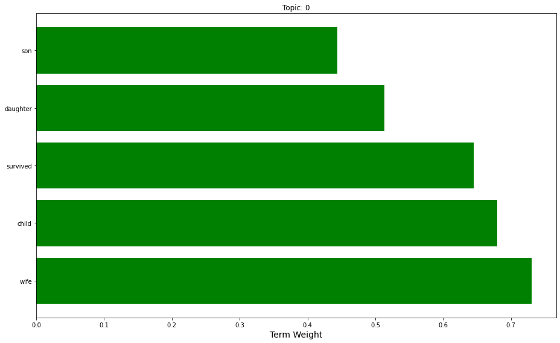

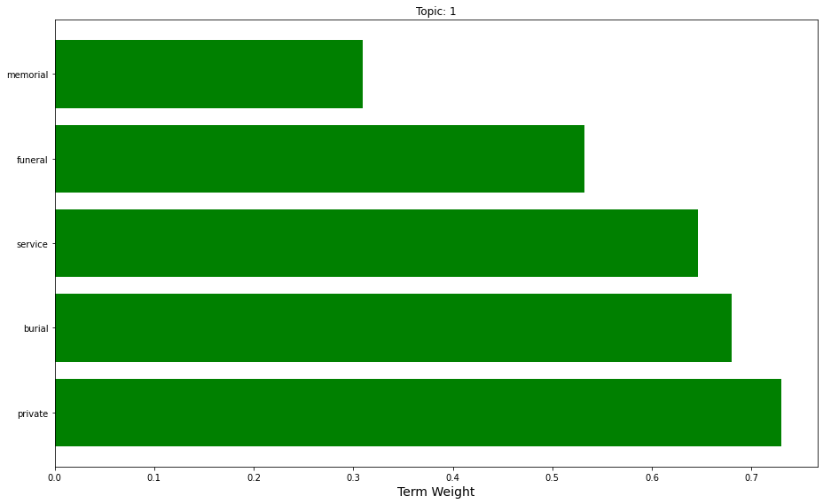

```python
# Display overall top K terms for each topic for analysis
analyser=Analyser()
analyser.plot_top_term_weights(modMan,topKterms)
```

# Step 12: Split the original documents into test and train sets

```
Lable is not evenly distributed,so have to stratify preparing training data model classification
```

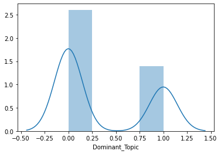

```python
# Analyse the distibution of the target lable.
print('Lable is not evenly distributed,so have to stratify preparing training data model classification')
analyser.distplotlabel(docMan.getDataLables(),"Dominant_Topic")
```

```python
# Get the data and train the Classification model
X_train, X_test, y_train, y_test = docMan.getTrainAndTestData(True)
```

# Step 13: Carry out classification modelling

```python
y_pred=modMan.trainAndPedict_NaiveBayesClassificationModel(X_train, X_test, y_train,modMan.getTFIDFVectorizer() )
```

```
(254, 1657)
(110, 1657)
```

# Step 14: Evaluate the results. Determine if there is a need to return to prior steps.

```
Accuracy: 0.7545454545454545
Precision: 0.8214876033057852
Recall: 0.7545454545454545
              precision    recall  f1-score   support

           0       0.73      1.00      0.84        72
           1       1.00      0.29      0.45        38

    accuracy                           0.75       110
   macro avg       0.86      0.64      0.65       110
weighted avg       0.82      0.75      0.71       110
```

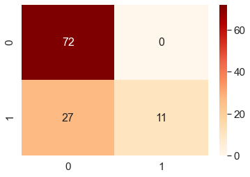

```python
# Evaluate model
from sklearn import metrics
cmArr=metrics.confusion_matrix(y_test, y_pred)
numOfUniqueLables=docMan.getNoOfUniqueLabel()
analyser.plotConfusionMatrix(cmArr,numOfUniqueLables)

print("Accuracy:",metrics.accuracy_score(y_test, y_pred))
print("Precision:",metrics.precision_score(y_test, y_pred,average='weighted'))
print("Recall:",metrics.recall_score(y_test, y_pred,average='weighted'))
print(metrics.classification_report(y_test, y_pred))
```

### Question 1: Was the outcome of the topic modelling and classification satisfactory? Please elaborate on your answers.

As for the classification,given the unsatisfactory no of topics found, and being able to detect with 0.75 accuracy is quite reasonable

### Question 2: Describe at least 3 issues that you have encountered with the data source. What text pre-preocessing methods did you apply to address these assumes?

1. The data souce is in the hundreds and to visually inspect all of them to get sense of the topic is impossible. A selective visual inspection is done to check on any discprepancies of the characters for example make sure the text does not contain non english characters. A printout of all words is also done at output/ALL_Words.xlsx to check on the words after cleaning is complete
2. There words which has the same root word. So lemmatization is done to reduce these words to the root form and remove any duplicated words once lemmatized.
3. Even after removing punctuation and root words, there are instances where there is a single character alphabet or words which are up to 2 characters long. such as 'a' 'as' 'go'. These words on their own are of little meaniing so they are removed as well

### Question 3: Describe some key takeaways you have learnt from this assignment.

1. Do not have any expectation beforehand on the number of topics which can be discovered
2. Cleaning data properly is important as it can affect the coherance value thus affecting accuracy of classifying documents
3. Cleaning data is a labour intensive and iterative process
4. It is impossible to visually inspect hundred of corpuses to get a sense of of the topics that is present
5. Implementing NMF topic modelling with TF-IDF vectorizer gave a slighly better result than using LDA and Count vectoirzer. I did implement at TIPP_NLP_LDA-Count.py for side comparison purposes LDA gave more topics but they are harder to identfy what each topics represents
6. The sequnce when cleaning data is important. such as removing stop words shld be done after removing punctuation